# Bayesian Modelling in RStan

27/05/2019

## The Plan

- Fitting our first model in RStan.
- Exploring some more advanced techniques for regression modelling.

Follow along with the [GitHub](https://github.com/EdJeeOnGitHub/rstan-example) repo on your own machines locally, or use a containerised binder session (doesn’t require RStan installation):

## What is Stan?

[Stan](https://mc-stan.org/) takes the difficult parts out of Markov Chain Monte Carlo (MCMC) and statistical computation.

Essentially it’s an interface to a bunch of linear algebra written in C++ and some probability density functions.

Stan lets us focus on writing model code that approximately resembles how we write Bayesian models with pen and paper.

[figure not shown]

## What is RStan?

RStan is just a wrapper around Stan that lets us access Stan from R.

We don’t need to use RStan, instead we could use:

- Python, PyStan.
- Shell, CMDStan.
- MATLAB, MatlabStan.
- Julia, Stan.jl.
- Stata, StataStan (if you **really** want to).

However, RStan is the most mature option with the largest community and a rich ecosystem of supporting packages ([rstanarm](https://mc-stan.org/rstanarm/), brms, [tidybayes](http://mjskay.github.io/tidybayes/)…).

## Why Stan?

- Stan is more flexible than alternative Bayesian offerings such as JAGS and BUGS.
- Stan’s MCMC methods use **Hamiltonian Monte Carlo** rather than Gibbs sampling or Metropolis-Hastings.
  - This is sort of a big deal.
- Models we couldn’t dream of fitting with Gibbs or MH are now (relatively) easy to fit.

## Our First Model

The “hello world!” of Bayesian modelling in Stan is the [eight schools experiment](https://github.com/stan-dev/rstan/wiki/RStan-Getting-Started) (Rubin 1981, Gelman et al 2003).

We want to find the effect of specialist coaching on SAT test scores. The programme was implemented in parallel across 8 different schools:

| y | 28 | 8 | -3 | 7 | -1 | 1 | 18 | 12 |
| --- | --- | --- | --- | --- | --- | --- | --- | --- |
| sigma | 15 | 10 | 16 | 11 | 9 | 11 | 10 | 18 |
| school | 1 | 2 | 3 | 4 | 5 | 6 | 7 | 8 |

## The Model:

\[ \begin{aligned} y_j & \sim \text{Normal}(\theta_j, \sigma_j), \ j = 1,...,8 \\ \theta_j &\sim \text{Normal}(\mu, \tau), \ j = 1,...,8 \\ \sigma_j & \ \text{known.} \end{aligned} \] With pretty standard priors:

\[ \begin{aligned} \mu &\sim \text{Normal}(0, 5) \\ \tau &\sim \text{Cauchy}^+(0, 5) \\ \newline \theta_j &\sim \text{Normal}(\mu, \tau) \end{aligned} \] Where do our priors come from?

The same place as our likelihood - or the [internet!](https://github.com/stan-dev/stan/wiki/Prior-Choice-Recommendations)

## data

We create a `.stan` file named `eight_school_centred.stan` (you can find it under the `stan/` folder in the repo).

Each Stan file contains a `data` modelling block:

```stan
data {
  int<lower=0> J; // N schools
  real y[J]; // treatment indexed by J
  real<lower=0> sigma[J]; // s.e. indexed by J
}
```

We need to set up our data in R accordingly:

```r
school_data <- list(J = 8,
                    y = c(28,  8, -3,  7, -1,  1, 18, 12),
                    sigma = c(15, 10, 16, 11,  9, 11, 10, 18))
```

## parameters

The parameters model block is pretty simple too:

```stan
parameters {
  real mu;
  real<lower=0> tau;
  real theta[J];
}
```

## model

Here we specify the likelihood and our priors:

```stan
model {
  // Our "population" priors
  mu ~ normal(0, 5); // location
  tau ~ cauchy(0, 5); // scale

  // The "lower rung" of the hierarchy ladder
  theta ~ normal(mu, tau);

  // Our likelihood:
  y ~ normal(theta, sigma);
}
```

## Fitting the Model

```r
library(rstan)
options(mc.cores = parallel::detectCores()) # How many cores to use.
rstan_options(auto_write = TRUE) # Saves time on model re-compilation.
set.seed(1234)

# Compile the model
eight_school_centred_stan <- stan_model(file = "stan/eight_school_centred.stan")
# Fit the model
model_draws_centred <- sampling(eight_school_centred_stan,
                        data = school_data,
                        iter = 10000,
                        chains = 4)
```

```
## Warning: Examine the pairs() plot to diagnose sampling problems
```

## Inspecting the Model

```r
library(shinystan)
launch_shinystan(model_draws_centred)
```

## Fixing the Model

Divergent transition warnings is common when fitting hierarchical models.

We have three options:

- Reparametrise the model.
- Increase adapt_delta.
- Try different priors.

## Non-Centred Parametrisation

A lot of things we do in Bayesian modelling is with an eye towards numerical optimisation - this is one of them:

```stan
transformed parameters {
  real theta[J];
  for (j in 1:J){
    theta[j] = mu + tau * theta_tilde[j]; // theta's final form
  }
}
model {
  mu ~ normal(0, 5);
  tau ~ cauchy(0, 5);

  theta_tilde ~ normal(0, 1); // Will be N(mu, tau) after transform

  y ~ normal(theta, sigma);
}
```

Fitting the non-centred model and bumping `adapt_delta` up:

```r
eight_school_non_centred_stan <- stan_model(file = "stan/eight_school_non_centred.stan")
model_draws_ncp <- sampling(eight_school_non_centred_stan,
                        data = school_data,
                        iter = 10000,
                        chains = 4,
                        control = list(adapt_delta = 0.95))
```

## Reparametrisation Solves the Divergent Transition Problem

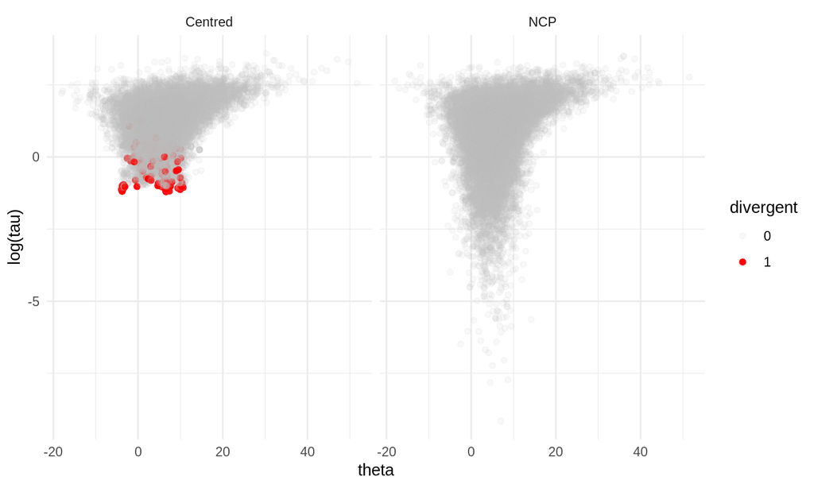

## Model Output

RStan’s default output:

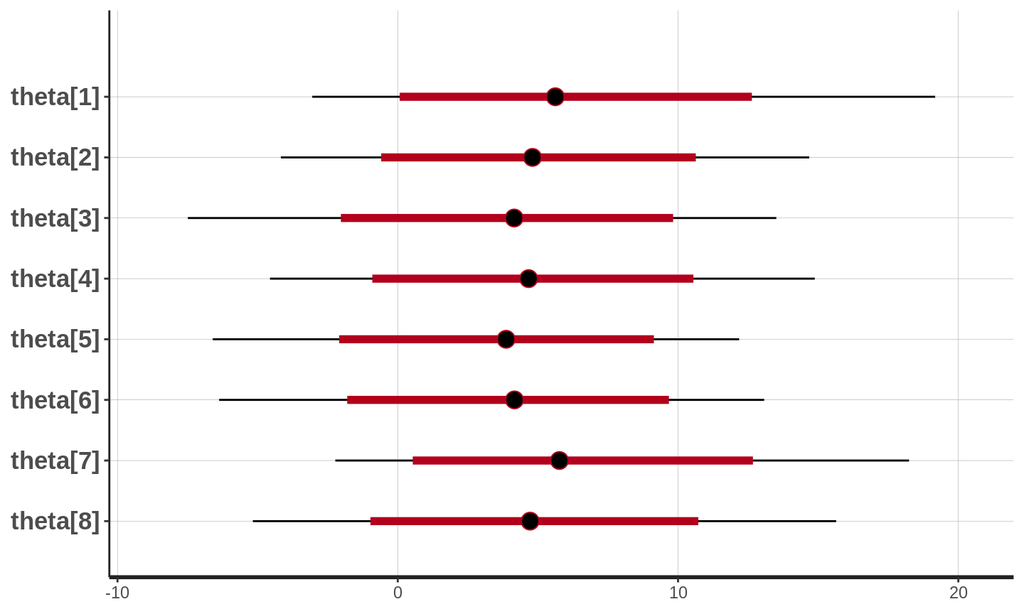

```r
plot(model_draws_ncp, pars = "theta")
```

## Tidybayes

```r
library(tidybayes)
library(ggstance)

tidy_ncp_draws <- model_draws_ncp %>%
  spread_draws(theta[j])  # Tidy model draws.

tidy_ncp_draws %>%
  median_qi() %>%
  to_broom_names() %>%
  mutate(model = "BHM",
         j = factor(j)) %>%
  bind_rows(tidy_no_pooling) %>% # Adding original data
  ggplot(aes(x = theta, xmin = conf.low, xmax = conf.high,
             y = j,
             colour = model)) +
  geom_pointrangeh(position = position_dodgev(height = 0.3)) +
  theme_minimal() +
  geom_vline(xintercept = 0, linetype = "longdash")
```

## No Pooling vs Partial Pooling

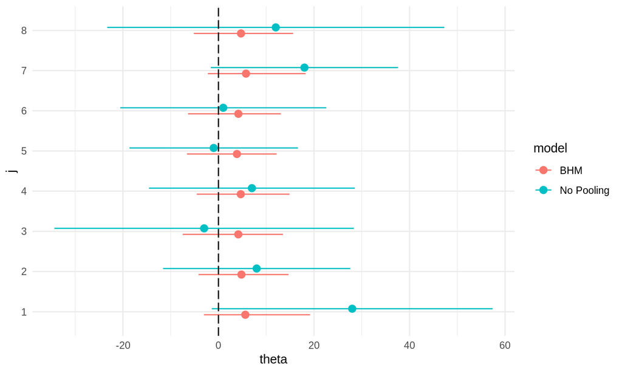

## ggridges

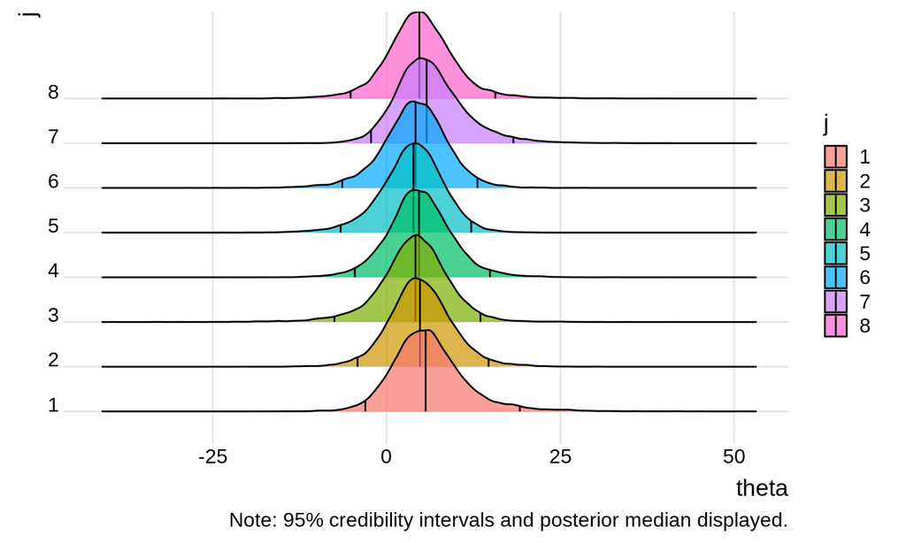

[ggmcmc](http://xavier-fim.net/post/resources-for-ggmcmc/) is a good alternative too (+ diagnostic plots).

## Posterior Predictive Checks

Bayesian analysis fully characterises the posterior distribution.

- This means we can simulate draws from the posterior and inspect goodness-of-fit.

```stan
generated quantities {
  real Y_rep[J];
  Y_rep = normal_rng(theta, sigma);
}
```

## Density Overlays

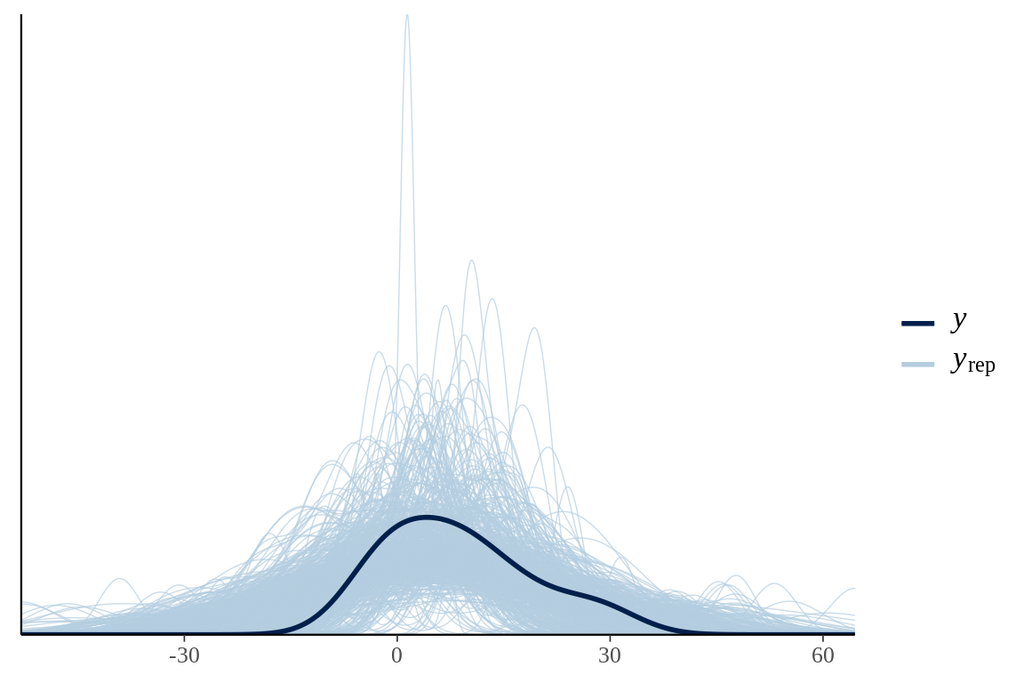

```r
library(bayesplot)
bayesplot_draws <- extract(model_draws_ncp)
ppc_dens_overlay(y = tidy_no_pooling$theta,
                 yrep = bayesplot_draws$Y_rep[1:500, ])
```

## Bayesian Test Statistics

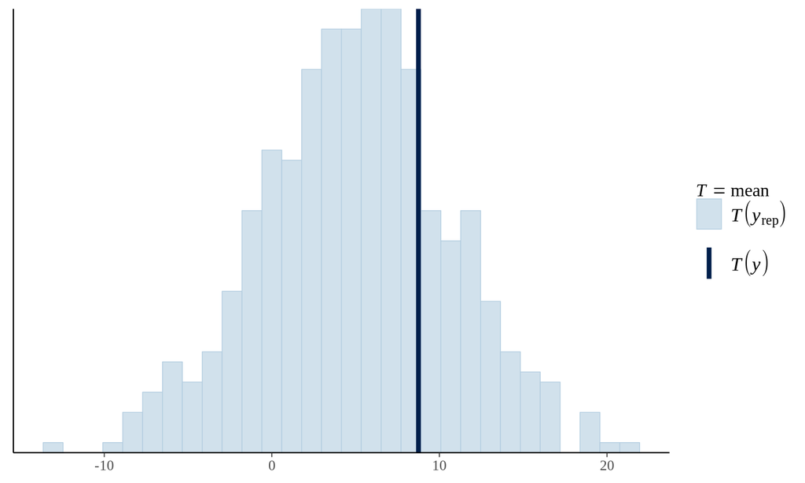

```r
ppc_stat(tidy_no_pooling$theta,
         bayesplot_draws$Y_rep[1:500, ],
         stat = "mean")
```

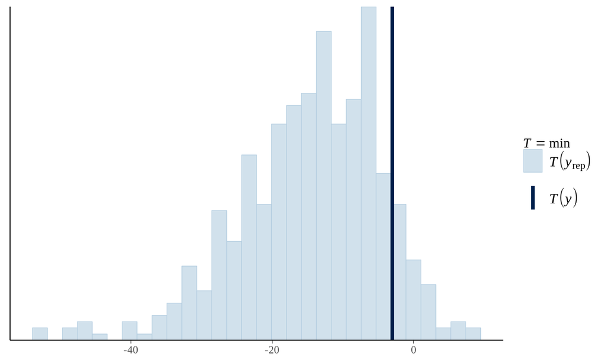

```r
ppc_stat(tidy_no_pooling$theta,
         bayesplot_draws$Y_rep[1:500, ],
         stat = "min")
```

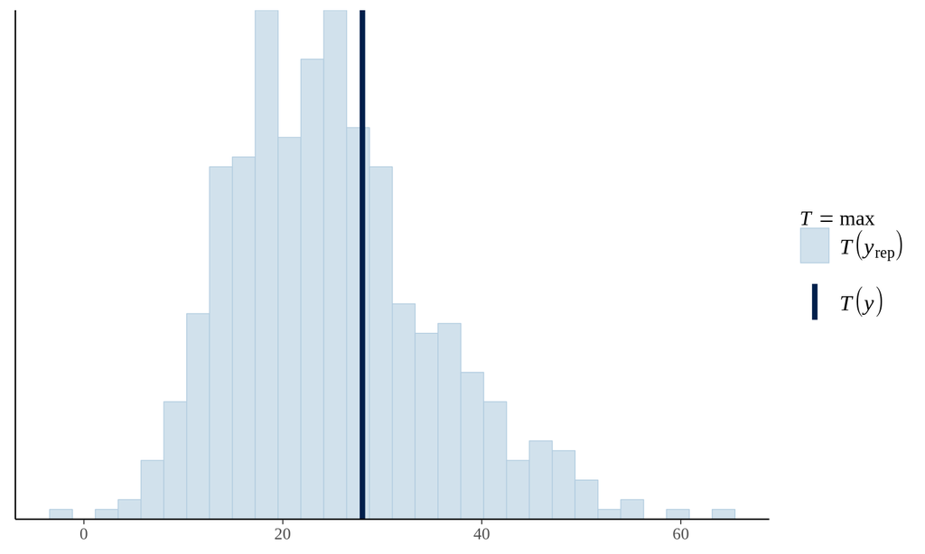

```r
ppc_stat(tidy_no_pooling$theta,
         bayesplot_draws$Y_rep[1:500, ],
         stat = "max")
```

## Bayesian Workflow

- Write down likelihood and choose priors.
- Code `.stan` file
  - data block
  - parameters block
  - (transformed parameters)
  - model block
  - generated quantities
- Recover simulated parameters.
- Fit true model.
- Inspect MCMC diagnostics, FOLK THEOREM!!!
- Explore results and PPCs.

## Fitting More Models

Next up we’re going to look at:

- Simple linear regression in rstan.
- QR decomposition and regression.
- Generalised linear models (logit, probit, etc.) and robust noise models.
- rstanarm and brms.

## Further Reading/References

- [rstan](https://mc-stan.org/users/interfaces/rstan.html)
- [Divergent Transition Bible](https://mc-stan.org/users/documentation/case-studies/divergences_and_bias.html)
- [Hamiltonian Monte Carlo](https://arxiv.org/abs/1701.02434)
- [Beginner Friendly Bayesian Modelling](https://www.amazon.co.uk/Students-Guide-Bayesian-Statistics/dp/1473916364)
- [More Involved Bayesian Modelling](http://www.stat.columbia.edu/~gelman/book/)

## Packages

- [tidybayes](http://mjskay.github.io/tidybayes/)
- [bayesplot](https://mc-stan.org/bayesplot/)
- [ggplot2](https://ggplot2.tidyverse.org/)
- [dplyr](https://dplyr.tidyverse.org/)
- [ggmcmc](http://xavier-fim.net/post/resources-for-ggmcmc/)
- [shinystan](https://mc-stan.org/shinystan/)
- [ggstance](https://cran.r-project.org/web/packages/ggstance/index.html)
- [purrr](https://purrr.tidyverse.org/)